# MasterDoc

#### skewnsess of EMD

```r
#skewness of EMD
# extract values
x <- normalized_ctrl_df$EMD

# calculate skewness (Fisher-Pearson Skewness)
n <- length(x)
m3 <- sum((x - mean(x, na.rm = TRUE))^3, na.rm = TRUE) / n
s3 <- (sum((x - mean(x, na.rm = TRUE))^2, na.rm = TRUE) / n)^(3/2)
skewness <- m3 / s3
print(paste("Skewness:", round(skewness, 4)))
```

```
## [1] "Skewness: 2.7529"
```

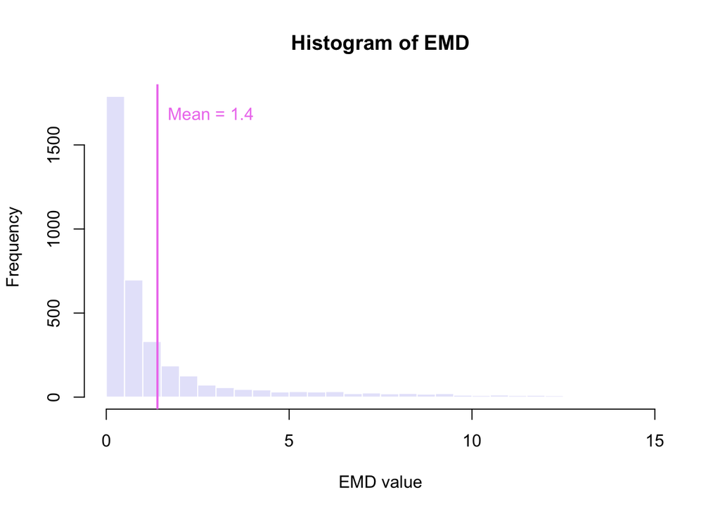

```r
# plot histogram
hist(x, breaks = 50, col = "lavender", main = "Histogram of EMD",
     xlab = "EMD value", border = "white")
abline(v = mean(x, na.rm = TRUE), col = "violet", lwd = 2)
text(mean(x, na.rm = TRUE), par("usr")[4]*0.9,
     labels = paste0("Mean = ", round(mean(x, na.rm = TRUE), 2)),
     col = "violet", pos = 4)
```

output: - skewness > 1 -> robust scaling can be applied #### scaling

```r
#robust scaling
normalized_ctrl_df$EMD_scaled <- robust_scale(normalized_ctrl_df$EMD)

#scale to 100%
normalized_ctrl_df$EMD_scaled_100 <- (normalized_ctrl_df$EMD_scaled/25)*100
```

### center of mass test

Goal: determine the center of mass of each protein for each treatment (in this case: mass = protein intensity) com <- sum(i * I_i) / sum(I_i) i = fractionnumber  
I_i = protein-intensity for the according fraction

```r
# center of mass
# function for calculating center of mass
center_of_mass <- function(values) {
  fracs <- seq_along(values)
  if (sum(values, na.rm = TRUE) == 0) return(NA)
  sum(fracs * values, na.rm = TRUE) / sum(values, na.rm = TRUE)
}
# function for calculating maximal possible COM shift
max_possible_com_shift <- function(values) {
  fracs <- seq_along(values)
  if (sum(values, na.rm = TRUE) == 0) return(NA)
}


# remove column with protein names
fractions_control <- normalized_ctrl_df[, 2:26]
fractions_rnase   <- normalized_rnase_df[, 2:26]

# calculate center of mass
com_control <- apply(fractions_control, 1, center_of_mass)
com_rnase   <- apply(fractions_rnase, 1, center_of_mass)

# Delta COM (Difference in Center of Mass)
delta_com <- com_rnase - com_control

# Absolute Delta COM
delta_com_abs <- abs(delta_com)

# Dataframe with results
center_of_mass_df <- data.frame(
  Protein = normalized_ctrl_df[[1]],
  COM_Control = com_control,
  COM_RNase = com_rnase,
  Delta_COM = delta_com,
  Absolute_Delta_COM = delta_com_abs
)
```

## classification: left or right shift

if delta_COM > 0: right shift if delta_COM < 0: left shift -> for proteins that are later on classifies as non-shifting this categtory is ignored

```r
# define direction of shift
center_of_mass_df$shift_direction <- ifelse(center_of_mass_df$Delta_COM > 0, "right shift",
                    ifelse(center_of_mass_df$Delta_COM < 0, "left shift",
                           "No Shift"))
```

#### skewness of center of mass

Goal: determine whether the delta center of mass values are skewed or not If skewed: robust scaling is possible

```r
#skewness of center of mass
# extract values
x <- center_of_mass_df$Delta_COM

# calculate skewness (Fisher-Pearson Skewness)
n <- length(x)
m3 <- sum((x - mean(x, na.rm = TRUE))^3, na.rm = TRUE) / n
s3 <- (sum((x - mean(x, na.rm = TRUE))^2, na.rm = TRUE) / n)^(3/2)
skewness <- m3 / s3
print(paste("Skewness:", round(skewness, 4)))
```

```
## [1] "Skewness: -2.3912"
```

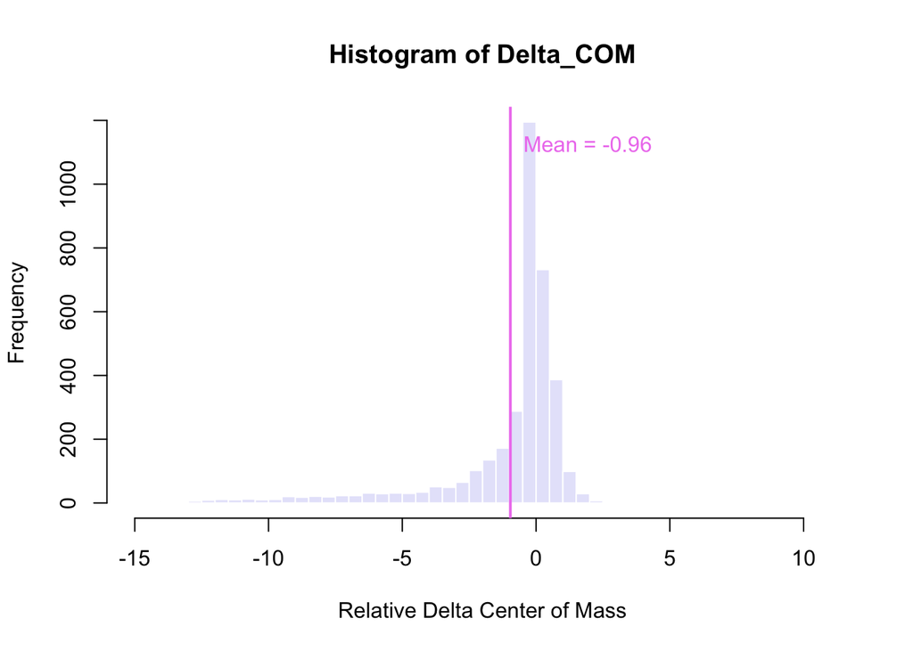

```r
# plot histogram
hist(x, breaks = 50, col = "lavender", main = "Histogram of Delta_COM",
     xlab = "Relative Delta Center of Mass", border = "white")
abline(v = mean(x, na.rm = TRUE), col = "violet", lwd = 2)
text(mean(x, na.rm = TRUE), par("usr")[4]*0.9,
     labels = paste0("Mean = ", round(mean(x, na.rm = TRUE), 2)),
     col = "violet", pos = 4)
```

Output: delta COM is left-skewed -> scaling is possible #### scaling Goal: transform testscore by centering at median and scaling based on the interquartile range

```r
#robust scaling
center_of_mass_df$COM_scaled <- robust_scale(center_of_mass_df$Absolute_Delta_COM)

# Normalize scaled values by max fraction delta (24)
center_of_mass_df$COM_scaled_norm <- center_of_mass_df$COM_scaled / 24

# Scale normalized values to percentage (0-100)
center_of_mass_df$COM_scaled_100 <- center_of_mass_df$COM_scaled_norm * 100
```

### wilcoxon statistic: position of maxima between replicates of conditions are compared

determine position of global maximum for each replicate of both conditions

```r
# determine global maxima from dataframes with still all 3 replicates in them

# prepare data
# remove protein-column
percent_ctrl <- percent_ctrl_df[, -1]
percent_rnase <- percent_rnase_df[, -1]

# define replicates as steps by 3
rep1_cols <- seq(1, ncol(percent_ctrl), by = 3)
rep2_cols <- seq(2, ncol(percent_ctrl), by = 3)
rep3_cols <- seq(3, ncol(percent_ctrl), by = 3)


# formula for extracting global maxima and their position
get_max_and_pos <- function(mat) {
  max_vals <- apply(mat, 1, max, na.rm = TRUE)
  max_pos <- apply(mat, 1, function(x) {
    if (all(is.na(x))) NA else which.max(x)
  })
  list(value = max_vals, pos = max_pos)
}

# formula for extracting position as numeric fraction value
extract_fraction_number <- function(name_vector) {
  as.numeric(sub("Fraction(\\d+)_Rep\\d+", "\\1", name_vector))
}

# apply formulas on both treatments
ctrl_r1 <- get_max_and_pos(percent_ctrl[, rep1_cols])
ctrl_r2 <- get_max_and_pos(percent_ctrl[, rep2_cols])
ctrl_r3 <- get_max_and_pos(percent_ctrl[, rep3_cols])

rnase_r1 <- get_max_and_pos(percent_rnase[, rep1_cols])
rnase_r2 <- get_max_and_pos(percent_rnase[, rep2_cols])
rnase_r3 <- get_max_and_pos(percent_rnase[, rep3_cols])

# define column names
names_r1 <- colnames(percent_ctrl)[rep1_cols]
names_r2 <- colnames(percent_ctrl)[rep2_cols]
names_r3 <- colnames(percent_ctrl)[rep3_cols]

# define protein names
protein_names <- percent_ctrl_df[, 1]

# save maxima results as dataframes
global_max_ctrl_df <- data.frame(
  Protein = protein_names,
  Max_Rep1 = ctrl_r1$value,
  Max_Rep2 = ctrl_r2$value,
  Max_Rep3 = ctrl_r3$value
)

global_max_rnase_df <- data.frame(
  Protein = protein_names,
  Max_Rep1 = rnase_r1$value,
  Max_Rep2 = rnase_r2$value,
  Max_Rep3 = rnase_r3$value
)

# save fraction position as dataframes
fraktion_pos_ctrl_df <- data.frame(
  Protein = protein_names,
  Max_Pos_Rep1 = extract_fraction_number(names_r1[ctrl_r1$pos]),
  Max_Pos_Rep2 = extract_fraction_number(names_r2[ctrl_r2$pos]),
  Max_Pos_Rep3 = extract_fraction_number(names_r3[ctrl_r3$pos])
)

fraktion_pos_rnase_df <- data.frame(
  Protein = protein_names,
  Max_Pos_Rep1 = extract_fraction_number(names_r1[rnase_r1$pos]),
  Max_Pos_Rep2 = extract_fraction_number(names_r2[rnase_r2$pos]),
  Max_Pos_Rep3 = extract_fraction_number(names_r3[rnase_r3$pos])
)
```

```r
# Prepare vectors to store results
p_values <- numeric(nrow(fraktion_pos_ctrl_df))         # p-values
wilcoxon_stats <- numeric(nrow(fraktion_pos_ctrl_df))   # custom test statistic (W = min(W+, W-))

# Loop through each protein (each row)
for (i in 1:nrow(fraktion_pos_ctrl_df)) {
  # Extract numeric values
  ctrl_values <- as.numeric(fraktion_pos_ctrl_df[i, 2:4])
  rnase_values <- as.numeric(fraktion_pos_rnase_df[i, 2:4])

  # Calculate paired differences
  diffs <- ctrl_values - rnase_values

  # Remove zero differences (they don't get ranked)
  non_zero_diffs <- diffs[diffs != 0]

  if (length(non_zero_diffs) == 0) {
    # All differences are 0 → test not defined
    p_values[i] <- 1
    wilcoxon_stats[i] <- 3
  } else {
    # Compute ranks of absolute differences
    ranks <- rank(abs(non_zero_diffs))

    # W+ = sum of ranks for positive differences
    W_plus <- sum(ranks[non_zero_diffs > 0])

    # W- = sum of ranks for negative differences
    W_minus <- sum(ranks[non_zero_diffs < 0])

    # Test statistic: the minimum of both
    W_stat <- min(W_plus, W_minus)

    # Compute the p-value using wilcox.test (only for p-value, not for statistic)
    test_result <- wilcox.test(ctrl_values, rnase_values, paired = TRUE, exact = FALSE)

    # Store results
    p_values[i] <- test_result$p.value
    wilcoxon_stats[i] <- W_stat
  }
}

# Combine the results
Wilcoxon_Pos_Max_Manual <- data.frame(
  Protein = fraktion_pos_ctrl_df[[1]],
  P_value = p_values,
  Wilcoxon_statistic = wilcoxon_stats
)
```

```r
#skewness of Wilcoxon-statistic Position of maxima
# extract values
x <- Wilcoxon_Pos_Max_Manual$Wilcoxon_statistic

# calculate skewness (Fisher-Pearson Skewness)
n <- length(x)
m3 <- sum((x - mean(x, na.rm = TRUE))^3, na.rm = TRUE) / n
s3 <- (sum((x - mean(x, na.rm = TRUE))^2, na.rm = TRUE) / n)^(3/2)
skewness <- m3 / s3
print(paste("Skewness:", round(skewness, 4)))
```

```
## [1] "Skewness: -0.0867"
```

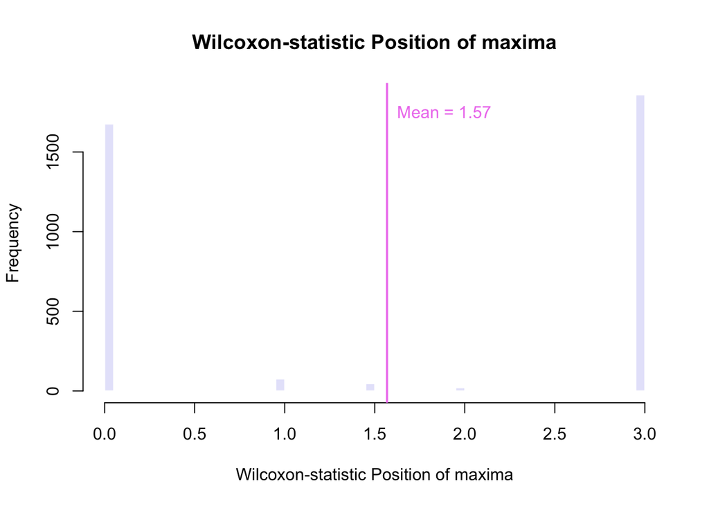

```r
# plot histogram
hist(x, breaks = 50, col = "lavender", main = "Wilcoxon-statistic Position of maxima",
     xlab = "Wilcoxon-statistic Position of maxima", border = "white")
abline(v = mean(x, na.rm = TRUE), col = "violet", lwd = 2)
text(mean(x, na.rm = TRUE), par("usr")[4]*0.9,
     labels = paste0("Mean = ", round(mean(x, na.rm = TRUE), 2)),
     col = "violet", pos = 4)
```

output: - skewness -1 < -0.0867 < 1 -> robust scaling cannot be applied -> error in Wilcoxon test was recognized too late -> there was no time to find a better suited scaling method for all tests -> for consistency robust scaling was applied nonetheless

#### scaling

```r
#robust scaling
Wilcoxon_Pos_Max_Manual$Wilcoxon_statistic_scaled<- robust_scale(Wilcoxon_Pos_Max_Manual$Wilcoxon_statistic)

#scale to 100%: maximum wilcoxon statistic is sum of ranks (1+2+3 = 6)
Wilcoxon_Pos_Max_Manual$Wilcoxon_statistic_scaled_100 <- (Wilcoxon_Pos_Max_Manual$Wilcoxon_statistic_scaled/6)*100
```

### test score dataframe

- contains the results of all tests

```r
#define dataframe for all test scores of all proteines
test_scores_combined_df <- data.frame(
  Protein = normalized_ctrl_df$Protein,
  Shift_Distance_ctrl_to_rnase = shift_result$Shift_Distance_scaled_100,
  Shift_direction_ctrl_to_rnase = center_of_mass_df$shift_direction,
  amplitude_changes = amplitude_changes$changes_scaled_100,
  EMD = normalized_ctrl_df$EMD_scaled_100,
  Center_of_Mass = center_of_mass_df$COM_scaled_100,
  Wilcoxon_statistic_Max = Wilcoxon_Pos_Max_Manual$Wilcoxon_statistic_scaled_100
)

#check that no NAs were created
sum(is.na(test_scores_combined_df))
```

```
## [1] 0
```

# determine reference proteins

- A dataframe from RDeeP is loaded, which indicates how often each protein has been classified as RNA-binding
- This dataframe includes proteins identified as RNA-binding in any human cell type

simplifications and limitations: - By using this reference, we ignore cell line–specific variation in RNA-binding behavior - The dataset refers to RNA-binding proteins (RBPs), not necessarily to RNA-dependent proteins (RDPs) ->Therefore, the model can only identify RNA-binding proteins, not all RNA-dependent ones

```r
library(DT)

# read data
url <- "https://raw.githubusercontent.com/MichelaPozzi/2025-topic-03-group-04/main/table_RBP_lists.csv"
lines <- readLines(url, encoding = "UTF-8")
header <- unlist(strsplit(lines[6], ","))
data <- read.csv(text = lines[7:length(lines)], header = FALSE, sep = ",", stringsAsFactors = FALSE)
colnames(data) <- header

# depict datatable
datatable(data, filter = "top", options = list(pageLength = 25))
```

|  |  | NA | NA | NA | NA | NA | NA | NA | NA | NA | NA | NA | NA | NA | NA | NA | NA | NA | NA | NA | NA | NA | NA | NA |
| --- | --- | --- | --- | --- | --- | --- | --- | --- | --- | --- | --- | --- | --- | --- | --- | --- | --- | --- | --- | --- | --- | --- | --- | --- |
| 1 | Entry_Name | Uniprot_ID | Gene_Name | Times_Listed_as_RBP | R_DeeP_shift | Baltz_2012 | Castello_2012 | Beckmann_2015 | Castello_2016 | Conrad_2016 | Mullari_2017 | Bao_2018 | Perez_Perri_2018 | Trendel_2018 | Gene_Ontology_RNA_Binding | Cook_2011 | Kwon_2013 | Ray_2013 | Gerstberger_2014 | He_2016 | Hendrickson_2016 | Sundararaman_2016 | Brannan_2016 | Treiber_2017 |
| 2 | CSTF2_HUMAN | P33240 | CSTF2 | 18 | X | X | X | X | X | X | X | X | X | X | X | X | X | X | X | X |  | X | X | X |
| 3 | HNRH1_HUMAN | P31943 | HNRNPH1 | 18 | X | X | X | X | X | X | X | X | X | X | X | X | X | X | X | X | X | X |  | X |
| 4 | HNRPL_HUMAN | P14866 | HNRNPL | 18 | X | X | X | X | X | X | X | X | X | X | X | X | X | X | X | X |  | X | X | X |
| 5 | IF2B1_HUMAN | Q9NZI8 | IGF2BP1 | 18 | X | X | X | X | X | X | X | X | X | X | X | X | X | X | X | X |  | X | X | X |
| 6 | RBM10_HUMAN | P98175 | RBM10 | 18 | X | X | X | X | X | X | X | X | X | X | X | X | X | X | X | X |  | X | X | X |
| 7 | RBM45_HUMAN | Q8IUH3 | RBM45 | 18 |  | X | X | X | X | X | X | X | X | X | X | X | X | X | X | X |  | X | X | X |
| 8 | SAFB1_HUMAN | Q15424 | SAFB | 18 | X | X | X | X | X | X | X | X | X | X | X | X | X | X | X | X |  | X | X | X |
| 9 | SF01_HUMAN | Q15637 | SF1 | 18 | X | X | X | X | X | X | X | X | X | X | X | X | X | X | X | X |  | X | X | X |
| 10 | SFPQ_HUMAN | P23246 | SFPQ | 18 | X | X | X | X | X | X | X | X | X | X | X | X | X | X | X | X |  | X | X | X |

[output cut: 4995 more lines]

```r
# save dataframe locally
write.csv(data, "mein_ergebnis.csv", row.names = FALSE)

#save result as dataframe
RBP_resources <- as.data.frame(data)
```

## negative control

Goal: identify proteins that have never or just once been listed as RBPs -> increases probability that these proteins do not actually interact with RNA in our cell line

```r
#identify proteins which can potentially be used as negative control
# proteins which were identified as RDPs not more than once
RNA_independent <- RBP_resources[RBP_resources[,4] %in% c(0,1), , drop = FALSE]
```

### select 550 porteins as negative control

- compare potential negative control proteins (listed in RDeeP dataframe) to proteins from our datafram -> find matches -> select 550 of those, ideally only those proteins that have never been caracterized as RBPs

```r
# check which of the potential proteins for negative control are actually contained in our dataset
row_subset <- RNA_independent[,1]
ref_row <- normalized_ctrl_df[,1]

# find common proteins
common_proteins_negative <- intersect(row_subset, ref_row)

# depict vector with common proteins
length(common_proteins_negative)
```

```
## [1] 822
```

```r
# select 550 proteins for negative control
# (to be combined later with 550 positive controls for a balanced dataset of 1100 proteins,
#  which is about 30% of all proteins, suitable for a 30/70 training-test split)

# Filter proteins with '0' in column 4 that are present in the dataset
zero_proteins <- intersect(RNA_independent[RNA_independent[,4] == 0, 1], normalized_ctrl_df[,1])

# Filter proteins with '1' in column 4 that are present in the dataset
one_proteins <- intersect(RNA_independent[RNA_independent[,4] == 1, 1], normalized_ctrl_df[,1])

# Count how many definite negatives we have
n_zero <- length(zero_proteins)

# Calculate how many proteins with '1' we need to sample to reach 550 total
n_fill <- 550 - n_zero

# Set random seed for reproducibility
set.seed(42)

# Randomly sample the required number of '1' proteins to fill the negative control set
sampled_one_proteins <- sample(one_proteins, n_fill)

# Combine the definite negatives and sampled proteins to form the final negative control set
negative_control <- c(zero_proteins, sampled_one_proteins)

# Confirm the length of the final negative control vector (should be 550)
length(negative_control)
```

```
## [1] 550
```

```r
# create dataframe negative control
# extract corresponding proteins from test_scores_combined_df
df_negative_control <- test_scores_combined_df[test_scores_combined_df$Protein %in% negative_control, ]
```

## positive control

Goal: identify proteins that have listed as RBPs most often

```r
#identify proteins which can potentially be used as positive control
RNA_dependent <- RBP_resources[RBP_resources[,4] %in% c(8, 9, 10, 11, 12, 13, 14, 15,16, 17, 18), , drop = FALSE]
```

### select 550 porteins as positive control

- compare potential positive control proteins (listed in RDeeP dataframe) to proteins from our datafram -> find matches -> select 550 of those

```r
#check which of the potential proteins for negative control are actually contained in our dataset
row_subset <- RNA_dependent[,1]
ref_row <- normalized_ctrl_df[,1]

# find common proteins
common_proteins_positive <- intersect(row_subset, ref_row)

# Output the number of common proteins
length(common_proteins_positive)
```

```
## [1] 550
```

```r
positive_control <- common_proteins_positive
```

```r
# create dataframe positive control
# extract corresponding proteins from test_scores_combined_df
df_positive_control <- test_scores_combined_df[test_scores_combined_df$Protein %in% positive_control, ]
# depict result
dim(df_positive_control)
```

```
## [1] 550   7
```